# Fuel Economy Data Exploration

## Introduction

This document explores a dataset of car models, vehicle class, transmission type, fuel type, fuel efficiency, CO2 emission scores and other attributes for approximately 4,000 cars

## Preliminary Wrangling

```python
# import all packages and set plots to be embedded inline
import numpy as np
import pandas as pd
import matplotlib.pyplot as plt
import seaborn as sb

%matplotlib inline
```

```python
# read the dataset from a csv file into pandas dataframe
fuel_econ= pd.read_csv('fuel-econ.csv')
```

```python
# print overview of data, shape and composition
print(fuel_econ.shape)
print(fuel_econ.dtypes)
print(fuel_econ.head(10))
```

```
(3929, 20)
id             int64
make          object
model         object
year           int64
VClass        object
drive         object
trans         object
fuelType      object
cylinders      int64
displ        float64
pv2            int64
pv4            int64
city         float64
UCity        float64
highway      float64
UHighway     float64
comb         float64
co2            int64
feScore        int64
ghgScore       int64
dtype: object
      id        make           model  year           VClass  \
0  32204      Nissan            GT-R  2013  Subcompact Cars
1  32205  Volkswagen              CC  2013     Compact Cars
2  32206  Volkswagen              CC  2013     Compact Cars
3  32207  Volkswagen      CC 4motion  2013     Compact Cars
4  32208   Chevrolet  Malibu eAssist  2013     Midsize Cars
5  32209       Lexus          GS 350  2013     Midsize Cars
6  32210       Lexus      GS 350 AWD  2013     Midsize Cars
7  32214     Hyundai   Genesis Coupe  2013  Subcompact Cars
8  32215     Hyundai   Genesis Coupe  2013  Subcompact Cars
9  32216     Hyundai   Genesis Coupe  2013  Subcompact Cars

               drive              trans          fuelType  cylinders  displ  \
0    All-Wheel Drive    Automatic (AM6)  Premium Gasoline          6    3.8
1  Front-Wheel Drive  Automatic (AM-S6)  Premium Gasoline          4    2.0
2  Front-Wheel Drive     Automatic (S6)  Premium Gasoline          6    3.6
3    All-Wheel Drive     Automatic (S6)  Premium Gasoline          6    3.6
4  Front-Wheel Drive     Automatic (S6)  Regular Gasoline          4    2.4
```

[output cut: 14 more lines]

```
7   89    0  17.4460  21.7946  26.6295   37.6731  20.6507  432        5
8   89    0  20.6741  26.2000  29.2741   41.8000  23.8235  375        6
9   89    0  16.4675  20.4839  24.5605   34.4972  19.3344  461        4

   ghgScore
0         4
1         6
2         5
3         5
4         8
5         6
6         5
7         5
8         6
9         4
```

```python
#number and category of unique categorical data
print(fuel_econ['make'].nunique())
print(fuel_econ['make'].unique())
print(fuel_econ['year'].nunique())
print(fuel_econ['year'].unique())
print(fuel_econ['VClass'].nunique())
print(fuel_econ['VClass'].unique())
print(fuel_econ['trans'].nunique())
print(fuel_econ['trans'].unique())
print(fuel_econ['fuelType'].nunique())
print(fuel_econ['fuelType'].unique())
print(fuel_econ['cylinders'].nunique())
print(fuel_econ['cylinders'].unique())
print(fuel_econ['feScore'].nunique())
print(fuel_econ['feScore'].unique())
print(fuel_econ['ghgScore'].nunique())
print(fuel_econ['ghgScore'].unique())
```

```
39
['Nissan' 'Volkswagen' 'Chevrolet' 'Lexus' 'Hyundai' 'Lincoln' 'Mazda'
 'Ford' 'Kia' 'Porsche' 'Scion' 'Subaru' 'Bentley' 'Audi' 'Buick'
 'Cadillac' 'Dodge' 'Infiniti' 'Roush Performance' 'Volvo' 'BMW' 'Jaguar'
 'Mercedes-Benz' 'Maserati' 'Rolls-Royce' 'MINI' 'Chrysler' 'Mitsubishi'
 'Toyota' 'Ferrari' 'Fiat' 'Suzuki' 'Acura' 'Honda' 'Lotus' 'Aston Martin'
 'Genesis' 'Alfa Romeo' 'Karma']
6
[2013 2014 2015 2016 2017 2018]
5
['Subcompact Cars' 'Compact Cars' 'Midsize Cars' 'Large Cars'
 'Minicompact Cars']
27
['Automatic (AM6)' 'Automatic (AM-S6)' 'Automatic (S6)' 'Automatic 8-spd'
 'Manual 6-spd' 'Automatic 6-spd' 'Automatic (S5)' 'Automatic 7-spd'
 'Automatic (AV-S6)' 'Automatic (S8)' 'Manual 7-spd' 'Automatic (AM-S7)'
 'Automatic (S7)' 'Automatic (variable gear ratios)' 'Manual 5-spd'
 'Automatic (AV-S8)' 'Automatic 4-spd' 'Automatic 5-spd' 'Automatic (AM7)'
 'Automatic (AV-S7)' 'Automatic 9-spd' 'Automatic (AM-S8)'
 'Automatic (A1)' 'Automatic (AM8)' 'Automatic (S9)' 'Automatic (S10)'
 'Automatic (AV-S10)']
5
['Premium Gasoline' 'Regular Gasoline' 'Diesel' 'Midgrade Gasoline'
 'Natural Gas']
7
[ 6  4  8 12  5  3  2]
10
[ 4  6  5  8  7  2  3  9 10  1]
10
[ 4  6  5  8  7  2  3  9 10  1]
```

```python
# convert 'year', 'cylinders', 'feScore' and 'ghgScore' to appropiate datatype
fuel_econ['year']= fuel_econ['year'].astype('category')
print(fuel_econ['year'].dtype)
fuel_econ['cylinders']= fuel_econ['cylinders'].astype('category')
print(fuel_econ['cylinders'].dtype)
fuel_econ['feScore']= fuel_econ['feScore'].astype('category')
print(fuel_econ['feScore'].dtype)
fuel_econ['ghgScore']= fuel_econ['ghgScore'].astype('category')
print(fuel_econ['ghgScore'].dtype)
```

```
category
category
category
category
```

```python
# convert 'year', 'VClass', and 'cylinders' into ordered categorical types
ordinal_var_dict = {'year': [2013, 2014, 2015, 2016, 2017, 2018],
                    'VClass': ['Minicompact Cars', 'Subcompact Cars', 'Compact Cars', 'Midsize Cars', 'Large Cars'],
                    'cylinders': [2, 3, 4, 5, 6, 8, 12],
                   'feScore': [1, 2, 3, 4, 5, 6, 7, 8, 9, 10],
                   'ghgScore': [1, 2, 3, 4, 5, 6, 7, 8, 9, 10]}

for var in ordinal_var_dict:
    ordered_var = pd.api.types.CategoricalDtype(ordered = True,
                                                categories = ordinal_var_dict[var])
    fuel_econ[var] = fuel_econ[var].astype(ordered_var)
```

```python
# convert 'trans' to either of Automatic or Manual
fuel_econ['trans']= fuel_econ['trans'].apply(lambda x: x.split()[0])
print(fuel_econ['trans'].nunique())
print(fuel_econ['trans'].unique())
```

```
2
['Automatic' 'Manual']
```

```python
# descriptive statistics for numeric data
print(fuel_econ.describe())
```

```
                 id        displ          pv2          pv4         city  \
count   3929.000000  3929.000000  3929.000000  3929.000000  3929.000000
mean   36006.724357     2.950573    23.660982    59.239247    21.830462
std     2189.349923     1.305901    37.724901    48.667549     6.246273
min    32204.000000     0.600000     0.000000     0.000000    10.540200
25%    34087.000000     2.000000     0.000000     0.000000    17.746900
50%    36020.000000     2.500000     0.000000    91.000000    20.823200
75%    37935.000000     3.600000    70.000000   100.000000    24.981400
max    39901.000000     7.000000   102.000000   127.000000    57.808800

             UCity      highway     UHighway         comb          co2
count  3929.000000  3929.000000  3929.000000  3929.000000  3929.000000
mean     28.044011    29.973842    42.850295    24.791339   376.564266
std       9.087195     5.747571     9.100423     6.003246    92.338892
min      12.900000    16.559400    21.800000    12.821700    29.000000
25%      22.200000    25.754200    36.000000    20.658100   315.000000
50%      26.400000    29.633800    42.200000    24.000000   369.000000
75%      32.264800    33.773100    48.900000    28.227100   429.000000
max      83.559800    59.416900    79.100000    57.782400   692.000000
```

```python
# ensure there are no missing values in the entire dataset
print(fuel_econ.isnull().sum())
```

```
id           0
make         0
model        0
year         0
VClass       0
drive        0
trans        0
fuelType     0
cylinders    0
displ        0
pv2          0
pv4          0
city         0
UCity        0
highway      0
UHighway     0
comb         0
co2          0
feScore      0
ghgScore     0
dtype: int64
```

```python
# drop 'id' column from dataset
fuel_econ.drop('id', inplace= True, axis= 1)
print("The dataset after wrangling looks like this:")
print(fuel_econ.head(20))
```

```
The dataset after wrangling looks like this:
          make           model  year           VClass              drive  \
0       Nissan            GT-R  2013  Subcompact Cars    All-Wheel Drive
1   Volkswagen              CC  2013     Compact Cars  Front-Wheel Drive
2   Volkswagen              CC  2013     Compact Cars  Front-Wheel Drive
3   Volkswagen      CC 4motion  2013     Compact Cars    All-Wheel Drive
4    Chevrolet  Malibu eAssist  2013     Midsize Cars  Front-Wheel Drive
5        Lexus          GS 350  2013     Midsize Cars   Rear-Wheel Drive
6        Lexus      GS 350 AWD  2013     Midsize Cars    All-Wheel Drive
7      Hyundai   Genesis Coupe  2013  Subcompact Cars   Rear-Wheel Drive
8      Hyundai   Genesis Coupe  2013  Subcompact Cars   Rear-Wheel Drive
9      Hyundai   Genesis Coupe  2013  Subcompact Cars   Rear-Wheel Drive
10     Hyundai   Genesis Coupe  2013  Subcompact Cars   Rear-Wheel Drive
11  Volkswagen              CC  2013     Compact Cars  Front-Wheel Drive
12     Lincoln         MKS AWD  2013       Large Cars    All-Wheel Drive
```

[output cut: 51 more lines]

### What is the structure of your dataset?

There are 3,929 cars in the dataset with 19 variables (9 numeric variables and 10 categorical variables). The cars in this dataset are of 39 unique makes, spanning from 2013 to 2018 and within 5 vehicle classes; minicompact cars, subcompact cars, compact cars, midsize cars and large cars.

### What is/are the main feature(s) of interest in your dataset?

I am interested in figuring out what features affect fuel efficiency (combined fuel efficiency mostly) and CO2 emissions.

### What features in the dataset do you think will help support your investigation into your feature(s) of interest?

I expect cylinders, displacement and vehicle class to have the most effects on combined fuel efficiency, while fuel type, fuel efficiency and vehicle class should have considerable impacts on CO2. It will be interesting to see what role manufacturing year also play on these features

## Univariate Exploration

First lets delve into each variable of interest and see how they are distributed.

Let's look at Combined Fuel Efficiency.

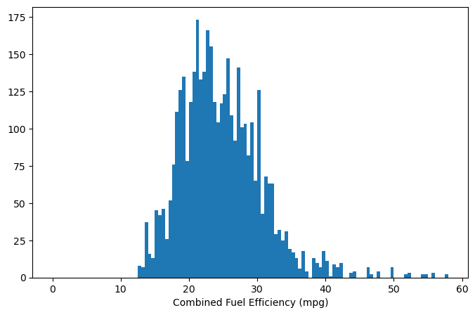

```python
# start with a standard_scaled hist plot
bins = np.arange(0, fuel_econ['comb'].max()+0.5, 0.5)

plt.figure(figsize=[8, 5])
plt.hist(data = fuel_econ, x = 'comb', bins = bins)
plt.xlabel('Combined Fuel Efficiency (mpg)')
plt.show()
```

`Comb` has a slightly right-skewed distribution, which is also slightly long-tailed, with a lot of points between 12 and 37, evenly distributed on either side of the median, and few points unevenly distributed from 38 to 58.

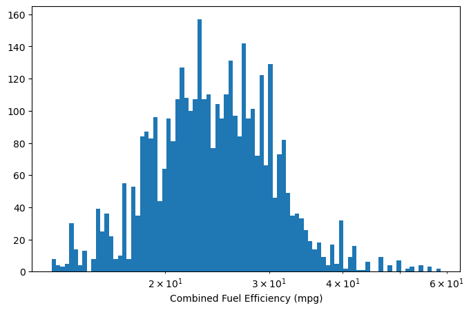

```python
# plot a log-scaled histogram of the distribution
bins = 10** np.arange(np.log10(fuel_econ['comb'].min()),np.log10(fuel_econ['comb'].max())+0.0075, 0.0075)

plt.figure(figsize=[8, 5])
plt.hist(data = fuel_econ, x = 'comb', bins = bins)
plt.xscale('log')
plt.xlabel('Combined Fuel Efficiency (mpg)')
plt.show()
```

Next let's look at CO2 emission

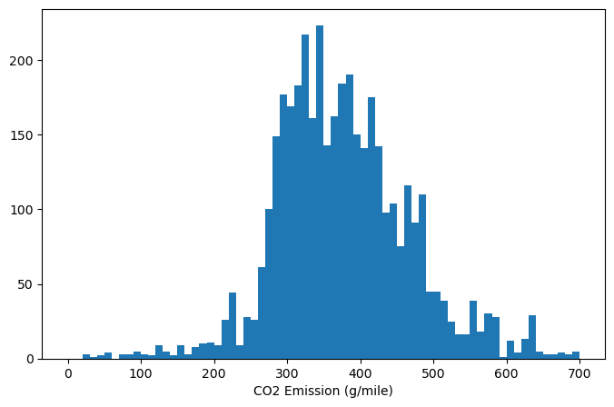

```python
# plotting CO2 emissions on a standard-scale histogram
bins = np.arange(0, fuel_econ['co2'].max()+10, 10)

plt.figure(figsize=[8, 5])
plt.hist(data = fuel_econ, x = 'co2', bins = bins)
plt.xlabel('CO2 Emission (g/mile)')
plt.show()
```

The plot of `CO2` is a left-skewed distribution, slightly bimodal, with peak points at 310 and 340. There a few points from 0 to 230, but the points increase sharply from 270 onwards to 310 before declining.

Let's now look at the distribution of the main categorical variables of interest

```python
default_color= sb.color_palette()[0]
```

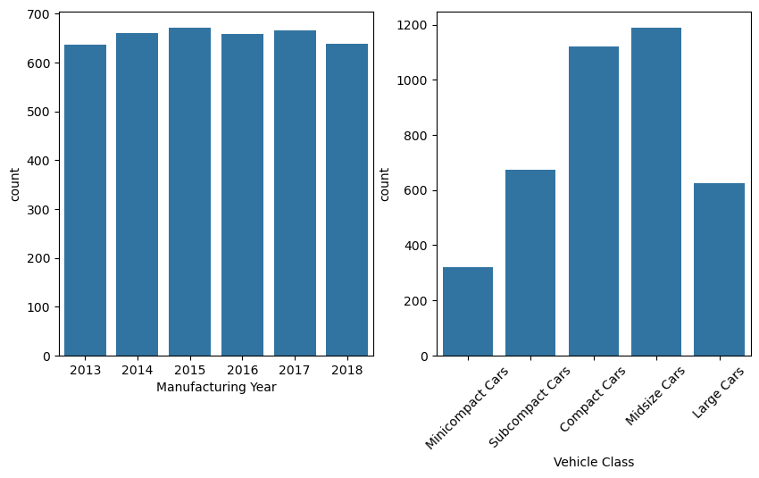

```python
#  plot the distribution of Vehicle Class and Manufacturing Year
plt.figure(figsize=[10,5])
plt.subplot(1, 2, 1)
sb.countplot(data= fuel_econ, x= 'year', color= default_color )
plt.xlabel('Manufacturing Year')


plt.subplot(1, 2, 2)
sb.countplot(data= fuel_econ, x= 'VClass', color= default_color )
plt.xlabel('Vehicle Class')
plt.xticks(rotation= 45);
```

The manufacturing years of cars in this dataset are all approximately evenly distributed throughout 2013 to 2018, with the most crs being manufactured in 2015 and 2017. Most of the cars are Midsize and Compact cars with mini-compact cars being the least frequent cars on this dataset.

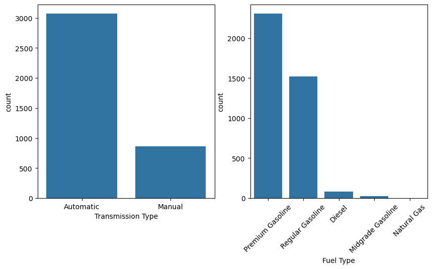

```python
# plot distribution of Transmission Type and Fuel Type
plt.figure(figsize=[10,5])
plt.subplot(1, 2, 1)
sb.countplot(data= fuel_econ, x= 'trans', color= default_color )
plt.xlabel('Transmission Type')


plt.subplot(1, 2, 2)
sb.countplot(data= fuel_econ, x= 'fuelType', color= default_color )
plt.xlabel('Fuel Type')
plt.xticks(rotation= 45);
```

There are approximately three times more automatic transmission cars than manual transmission cars in this dataset, with most cars using premium gasoline and regular gasoline fuel types.

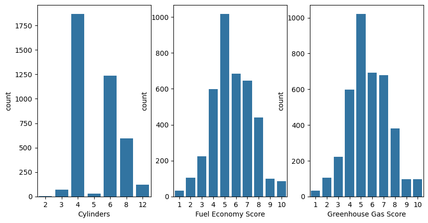

```python
# plot distribution of Cylinders, Greenhouse gas Score and Fuel Economy score
plt.figure(figsize=[10,5])
plt.subplot(1, 3, 1)
sb.countplot(data= fuel_econ, x= 'cylinders', color= default_color )
plt.xlabel('Cylinders')


plt.subplot(1, 3, 2)
sb.countplot(data= fuel_econ, x= 'feScore', color= default_color )
plt.xlabel('Fuel Economy Score')


plt.subplot(1, 3, 3)
sb.countplot(data= fuel_econ, x= 'ghgScore', color= default_color )
plt.xlabel('Greenhouse Gas Score');
```

Cars with 4 cylinders are the most common in this dataset, followed by 6-cylinder cars and 8-cylinder cars.

### Discussion

> The combined fuel efficiency variable has a slightly right-skewed distribution on a standard scale, with a lot of points between 12 and 37, evenly distributed on either side of the median, and few points unevenly distributed from 38 to 58.

> The plot of CO2 emission is a left-skewed distribution. There a few points from 0 to 230, but the points increase sharply from 270 onwards to 310 before declining.

> I had to re-engineer the `trans-type` column to the `trans` column to carry more workable data.

> I had to change data types of the `year`, `cylinders`, `feScore` and `ghgScore` columns, because although the data appear numeric, they are categorical data.

> I also had to order ordinal data.

## Bivariate Exploration

To start of with I will like to look at an overview of pair correlation of the variables

```python
numeric_vars = ['displ', 'comb', 'co2']
```

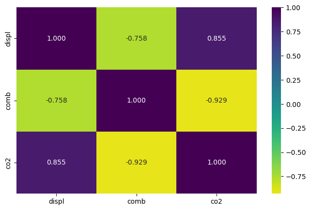

```python
# correlation plot of numeric variables of interest
plt.figure(figsize = [8, 5])
sb.heatmap(fuel_econ[numeric_vars].corr(), annot = True, fmt = '.3f',
           cmap = 'viridis_r', center = 0)
plt.show()
```

```
fuel_econ.shape= (3929, 19)
fuel_econ_sample.shape= (1000, 19)
```

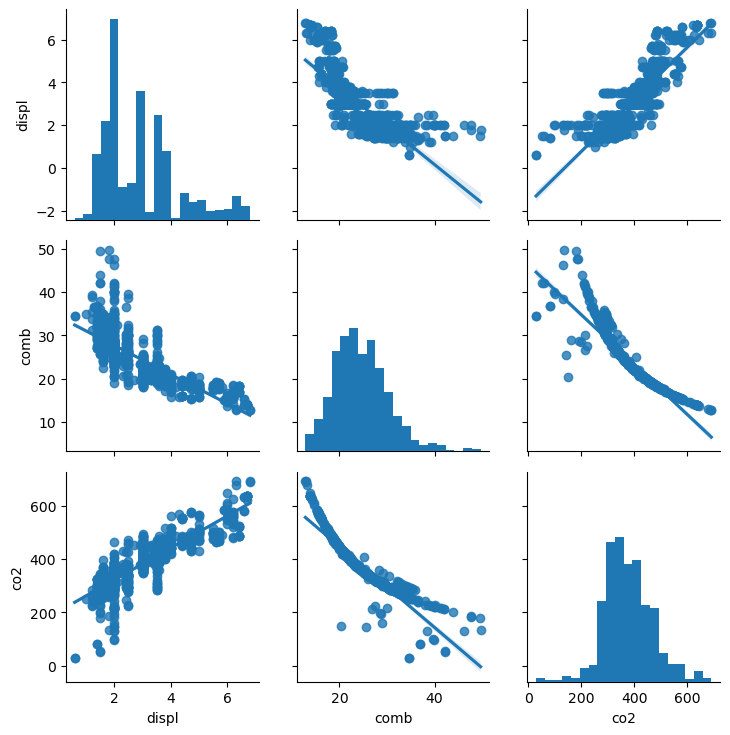

```python
# plot matrix: sample 1000 cars so that plots are clearer and still representative of the overall dataset
print("fuel_econ.shape=",fuel_econ.shape)
fuel_econ_sample = fuel_econ.sample(n=1000, replace = False)
print("fuel_econ_sample.shape=",fuel_econ_sample.shape)

g = sb.PairGrid(data = fuel_econ_sample, vars = numeric_vars)
g = g.map_diag(plt.hist, bins = 20);
g.map_offdiag(sb.regplot);
```

There's a negative correlation between combined fuel efficiency and displacement and a positive correlation between CO2 emmisions and displacement, each shown by their high negative correlation coefficient and positive correlation coefficient respectively.

But perhaps the most noteworthy observation is that there's a strong negative correlation between combined fuel efficiency and CO2 emissions, with a very high negative correlation coefficient.

This is what I expected to observe.

Let's see how this numeric variables correlate with categorical variables.

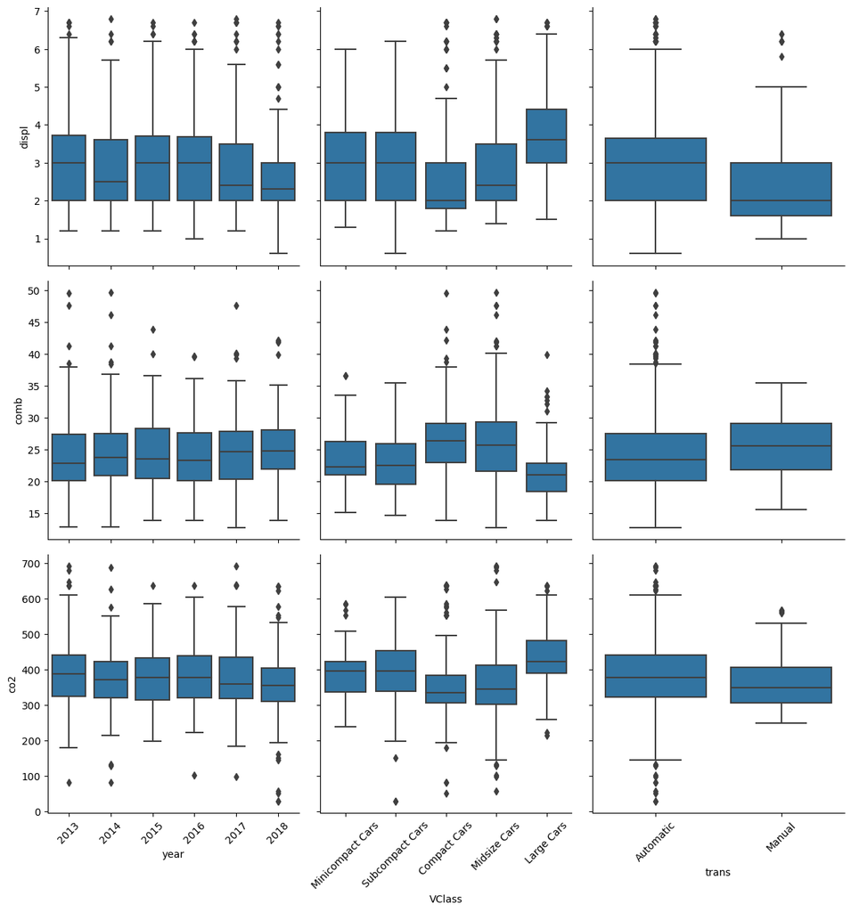

```python
# plot matrix of numeric features against year, VClass and trans
def boxgrid(x, y, **kwargs):
    default_color = sb.color_palette()[0]
    sb.boxplot(x=x, y=y, color=default_color)
    plt.xticks(rotation= 45)

plt.figure(figsize = [8, 8])
g = sb.PairGrid(data = fuel_econ_sample, y_vars = numeric_vars, x_vars = ['year', 'VClass', 'trans'],
                height = 4, aspect = 1)
g.map(boxgrid)
plt.show();
```

Unurprisingly cars in this dataset made in 2013 have the lowest combined fuel efficiency and the highest CO2 emissions. This is in line with the patterns we've seen so far.

Large cars are the least fuel efficient and have the highest CO2 emissions. Compact and Midsize cars are the highest fuel efficiency and the lowest CO2 emissions, again in line with the inverse correlation between fuel efficiency and CO2 emissions.

Automatic transmission types give higher displacements than Manual transmissions. It is however interesting to note that Manual transmissions show higher fuel efficiency on average, though this might not necessarily be the case given the high number of outliers evident in the plot.

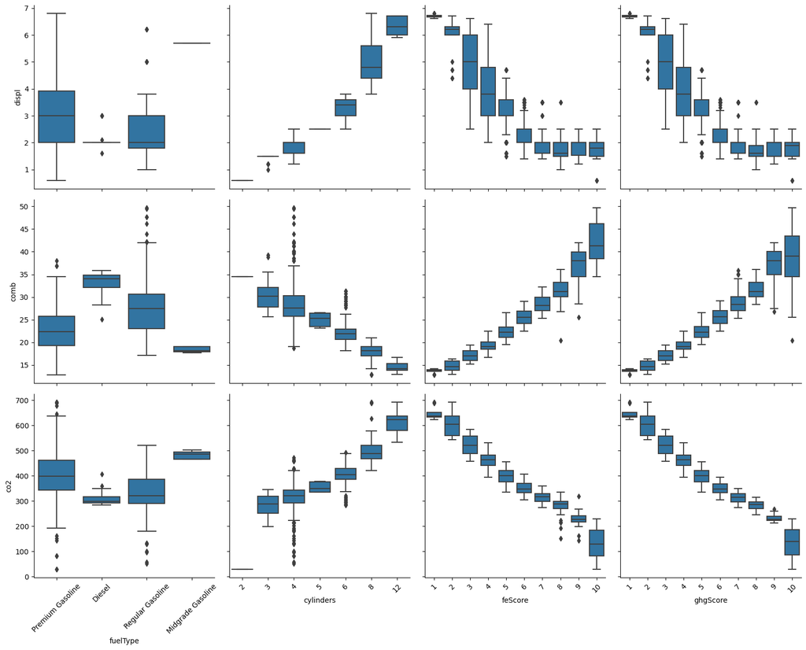

```python
# plot matrix of numeric features against fuelType, cylinders, feScore and ghgScore
plt.figure(figsize = [8, 8])
g = sb.PairGrid(data = fuel_econ_sample, y_vars = numeric_vars, x_vars = ['fuelType', 'cylinders', 'feScore', 'ghgScore'],
                height = 4, aspect = 1)
g.map(boxgrid)
plt.show();
```

Premium gasoline have lower combined fuel efficiency compared to regular and diesel and hence produce the most CO2 emissions of the three.

There's a positive correlation between the number of cylinders and the amount of displacement produced, with higher cylinders causing more displacement. This may explain the positive correlation between cylinders and CO2 emissions as it's already earlier established that there's a positive correlation between displacement and CO2 emissions. The inverse is true for combined fuel efficiency.

There's a positive correlation between combined fuel efficiency and fuel economy score. This is expected for obvious reasons. The inverse is the case for CO2 emissions as cars with low CO2 emissions have higher fuel economy scores.

The relationship between greenhouse gas score and these numeric features are identical to the ones seen in fuel economy score, further strengthening that these two categorical features have a very strong positive correlation

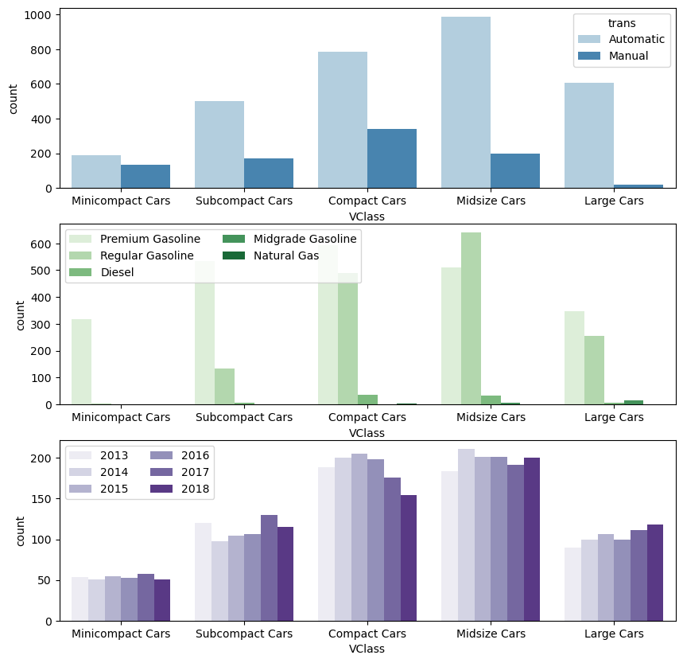

```python
# plot VClass vs. other categorical features
plt.figure(figsize = [10, 10])

# subplot 1: VClass vs. trans
plt.subplot(3, 1, 1)
sb.countplot(data = fuel_econ, x = 'VClass', hue = 'trans', palette = 'Blues')

# subplot 2: VClass vs. fuelType
ax = plt.subplot(3, 1, 2)
sb.countplot(data = fuel_econ, x = 'VClass', hue = 'fuelType', palette = 'Greens')
ax.legend(loc= 2, ncol = 2)

# subplot 3: VClass vs. year
ax = plt.subplot(3, 1, 3)
sb.countplot(data = fuel_econ, x = 'VClass', hue = 'year', palette = 'Purples')
ax.legend(ncol = 2)

plt.show()
```

In every class of vehicle premium gasoline is the most common fuel type with the exception of Midsize cars favoring regular gasoline more.

This dataset has more compact cars made in 2015 relative to other years, more subcompact in 2017 and more large cars in 2018, relative to other years.

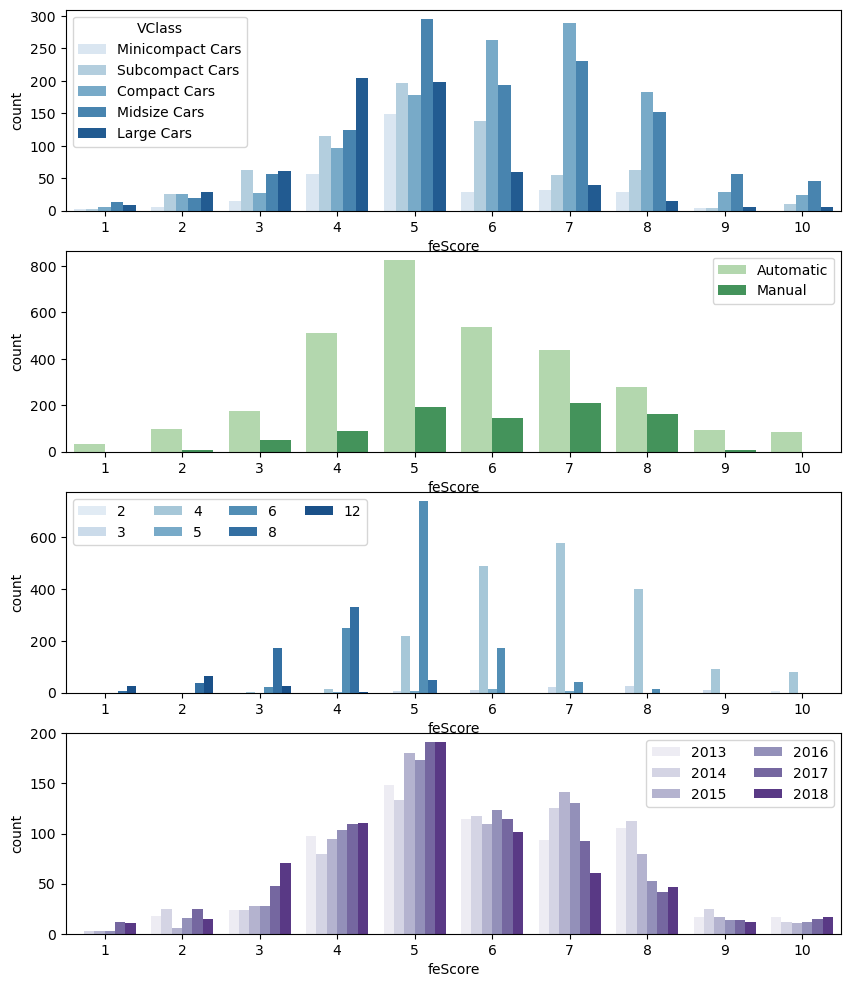

```python
# plot feScore vs. other categorical features
plt.figure(figsize = [10, 12])

# subplot 1: feScore vs. VClass
plt.subplot(4, 1, 1)
sb.countplot(data = fuel_econ, x = 'feScore', hue = 'VClass', palette = 'Blues')

# subplot 2: feScore vs. trans
ax = plt.subplot(4, 1, 2)
sb.countplot(data = fuel_econ, x = 'feScore', hue = 'trans', palette = 'Greens')
ax.legend(ncol = 1)

# subplot 3: feScore vs. cylinders
ax = plt.subplot(4, 1, 3)
sb.countplot(data = fuel_econ, x = 'feScore', hue = 'cylinders', palette = 'Blues')
ax.legend(loc = 2, ncol = 4)

# subplot 4: feScore vs. year
ax = plt.subplot(4, 1, 4)
sb.countplot(data = fuel_econ, x = 'feScore', hue = 'year', palette = 'Purples')
ax.legend(ncol = 2)

plt.show()
```

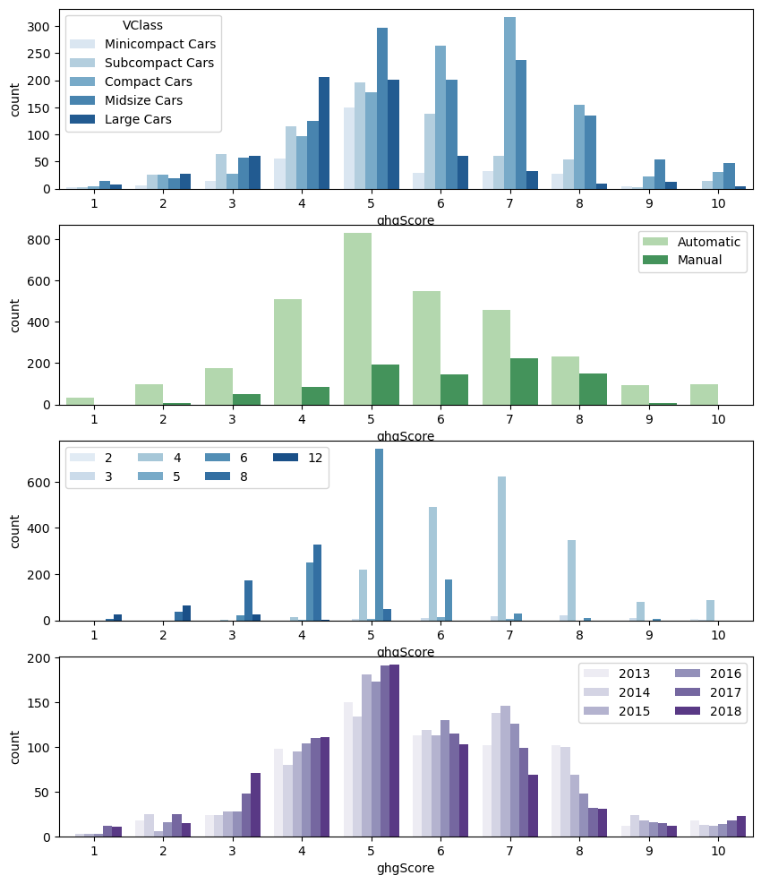

```python
# plot ghgScore vs. other categorical features
plt.figure(figsize = [10, 12])

# subplot 1: ghgScore vs. VClass
plt.subplot(4, 1, 1)
sb.countplot(data = fuel_econ, x = 'ghgScore', hue = 'VClass', palette = 'Blues')

# subplot 2: ghgScore vs. trans
ax = plt.subplot(4, 1, 2)
sb.countplot(data = fuel_econ, x = 'ghgScore', hue = 'trans', palette = 'Greens')
ax.legend(ncol = 1)

# subplot 3: ghgScore vs. cylinders
ax = plt.subplot(4, 1, 3)
sb.countplot(data = fuel_econ, x = 'ghgScore', hue = 'cylinders', palette = 'Blues')
ax.legend(loc = 2, ncol = 4)

# subplot 4: ghgScore vs. year
ax = plt.subplot(4, 1, 4)
sb.countplot(data = fuel_econ, x = 'ghgScore', hue = 'year', palette = 'Purples')
ax.legend(ncol = 2)

plt.show()
```

### Observations

> There's a strong negative correlation between combined fuel efficiency and CO2 emissions, with a very high negative correlation coefficient.

> Cars in this dataset made in 2013 have the lowest combined fuel efficiency and the highest CO2 emissions.

> Large cars are the least fuel efficient. Compact cars are the most fuel efficient.

> There's a positive correlation between the number of cylinders and the amount of displacement produced.

> There's a positive correlation between combined fuel efficiency and fuel economy score. The inverse is the case for CO2 emissions.

> Fuel economy score and Greenhouse gas score have a very strong positive correlation

## Multivariate Exploration

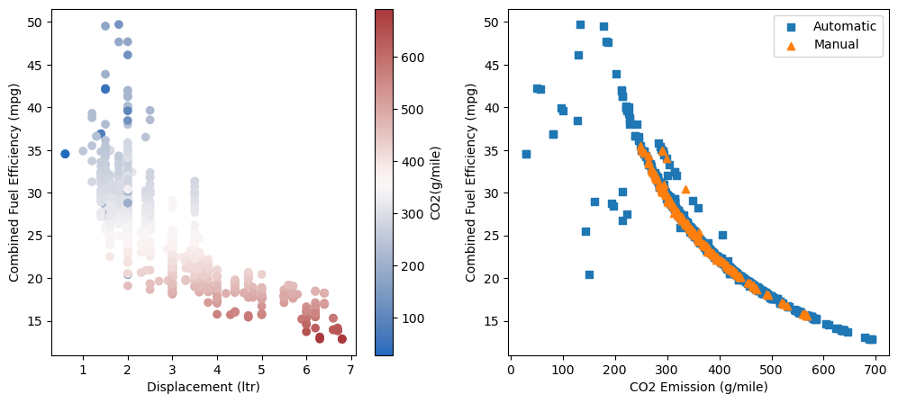

```python
plt.figure(figsize= [12, 5])

# plot of Comb vs. Displacement vs. CO2 emissions, showing the relationship between all 3 numeric features
plt.subplot(1, 2, 1)
plt.scatter(data= fuel_econ_sample, x= 'displ', y= 'comb', c = 'co2',
           cmap= 'vlag');
plt.colorbar(label= 'CO2(g/mile)')
plt.xlabel('Displacement (ltr)')
plt.ylabel('Combined Fuel Efficiency (mpg)')

# plot of Comb vs. CO2 emissions with transmission type as legend
plt.subplot(1, 2, 2)
trans_markers= [['Automatic', 's'],
               ['Manual', '^']]
for trans, marker in trans_markers:
    fuel_auto= fuel_econ_sample[fuel_econ_sample['trans'] == trans]
    plt.scatter(data= fuel_auto, x= 'co2', y= 'comb',
              marker= marker)
plt.xlabel('CO2 Emission (g/mile)')
plt.ylabel('Combined Fuel Efficiency (mpg)')
plt.legend(['Automatic', 'Manual']);
```

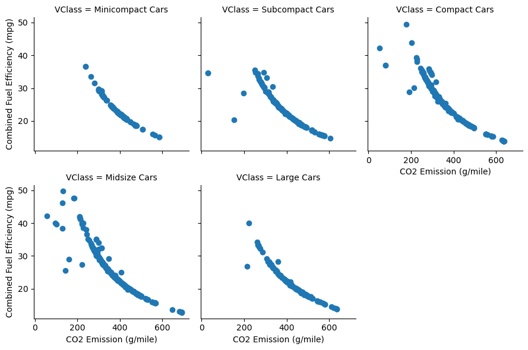

```python
# plot showing relationship between Comb and CO2 emission within the various vehicle slasses
g = sb.FacetGrid(data = fuel_econ_sample, col = 'VClass', col_wrap = 3, height = 3)
g.map(plt.scatter, 'co2', 'comb')
g.set_xlabels('CO2 Emission (g/mile)')
g.set_ylabels('Combined Fuel Efficiency (mpg)')

plt.show()
```

### Observations

> The observations from these plots further highlight and butress the points already established in the preceeding bivariate plots.